# peer assessment 1

### Are there differences in activity patterns between weekdays and weekends?

Creating the weekend/weekday factor variable:

```r
day.of.week = weekdays(activity$date)
activity2$wkd.or.wkday =
factor(day.of.week=="Saturday" | day.of.week=="Sunday")
levels(activity2$wkd.or.wkday) = c("weekday", "weekend")
```

Computing average number of steps per interval forweekdays and weekends separately:

```r
wkday.dat = activity2[activity2$wkd.or.wkday=="weekday",]
ave.num.steps.wkday = tapply(wkday.dat$steps, wkday.dat$interval, mean)

wkd.dat = activity2[activity2$wkd.or.wkday=="weekend",]
ave.num.steps.wkd = tapply(wkd.dat$steps, wkd.dat$interval, mean)
```

```r
dat = data.frame(interval = rep(seq(0,1435, by=5),2),
  ave.num.steps = c(as.vector(ave.num.steps.wkday), as.vector(ave.num.steps.wkd)),
  wkd.or.wkday = as.factor(rep(c("weekday", "weekend"), c(288,288))))
```

Creating the plot with the lattice library:

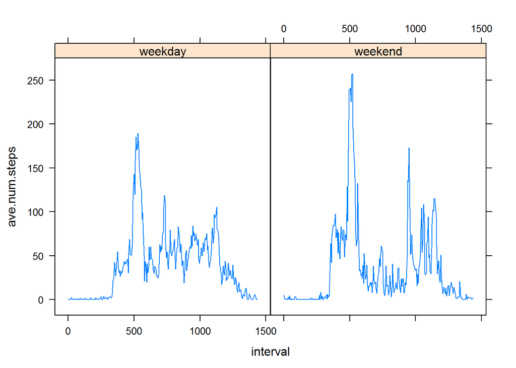

```r
library(lattice)
xyplot(ave.num.steps~ interval | wkd.or.wkday, type="l", data=dat)
```

Weekdays show more midday walking spread out over a period of several hours. On weekends, the morning spike is higher (more steps in the morning walk), mid-day numbers of steps decrease, and evening is more spikey and higher.